# Data Management and Visualization | Spring 2020 Midterm 01

Due: 18 may at 11:30

## Academic Honesty Statement

**THIS IS AN INDIVIDUAL ASSESSMENT, THIS DOCUMENT AND YOUR ANSWERS ARE FOR YOUR EYES ONLY. ANY VIOLATION OF THIS POLICY WILL BE IMMEDIATELY REPORTED TO THE MASTER CONDUCT BOARD.**

*Copy the text below, replacing the underscores with your name, and paste it in the report you submit, acknowledging that you have read and understood the abovementioned honesty statement.*

I, ____________, hereby state that I have not communicated with or gained information in any way from my classmates or anyone other than the Professors during this exam, and that all work is my own.

## Data

For this midterm, we will analyze trends in California wildfires, using the California Department of Forestry and Fire Protection (Cal Fire) Fire Perimeters Geodatabase. The main file we will use is the calfire data frame, which contains information on each wildfire bigger than 10 acres, the agency responsible for the management, the fire name, alarm and contention date, the surface affected and the cause, among other variables. To load this data frame, **be sure to include this code** at the beginning of your report:

```r
load("./data/calfire.rdata")
```

We will also use information on the damages caused by wildfires in California and the US, that we will load when needed.

All these data have been gathered by the Cal Fire and pre-processed and released by BuzzFeed news for the “Tidy Tuesday” visualization initiative (https://github.com/rfordatascience/tidytuesday)

## Instructions

We expect you to produce a complete, **knittable Rmarkdown document** that contains the text of the questions, the code chunks needed to answer them, and **some comments on the results obtained**. There are **10 questions**, each will be valued **1 point**, and one optional question that provides 1 extra credit if solved. You will have a total of **1.5 hours** to complete the exam. During this time, we will be available in the forum of the virtual campus of the UdL to solve any doubt. Once the time has expired, we will access your RStudio Cloud project and **copy the Rmarkdown file as it is at that moment**, with no possibility of later changes. If you finish before the time allowed, please let us know. We will value not only the final result and the code, but also the appropriate formatting and coding style (see below).

Good luck to everyone!

## Questions

### Question 1

Cal Fire uses the Imperial system of units. That means that fire surfaces are provided in acres (`gis_acres`). Create a new field in the data frame that contains the surface of each wildfire in hectares (of course, you can google to know which is the conversion rate)

```r
calfire <- calfire %>%
    mutate(sup_ha = gis_acres / 2.471)
```

### Question 2

Our dataset contains information on when the fire was detected, and when it was controlled. Make a table listing the fires that burned for the most time. For how long were they burning? Are they mostly recent fires or ancient fires? Do you see anything worth commenting?

```r
calfire %>%
    mutate(burning_time = cont_date-alarm_date) %>%
    arrange(desc(burning_time))
```

```
## # A tibble: 14,847 x 24
##       X1 objectid year_ state agency unit_id fire_name inc_num alarm_date
##    <dbl>    <dbl> <dbl> <chr> <chr>  <chr>   <chr>     <chr>   <date>
##  1 13308    18448  1990 CA    NPS    YNP     PIUTE     86      1990-08-13
##  2   124      124  2007 CA    USF    TNF     RALSTON   1443    2006-09-05
##  3 13206    18343  2006 CA    NPS    SMP     WESTLAKE  0000CW… 2006-07-08
##  4  8153    12651  2012 CA    CCO    KRN     LAVAL     1216604 2012-06-03
##  5 12440    17525  2013 CA    CDF    BTU     PANTHER   5648    2013-05-01
##  6 12410    17495  2013 CA    USF    ANF     POWERHOU… 2297    2013-05-30
##  7 13764    18930  2015 CA    USF    BDF     LAKE      7894    2015-06-17
##  8 14187    19355  2016 CA    USF    KNF     PONY      4500    2016-06-07
##  9 11224    16309  2008 CA    USF    KNF     ANTHONY … 54      2008-06-19
## 10 11223    16308  2008 CA    USF    KNF     CARIBOU   26      2008-06-21
## # … with 14,837 more rows, and 15 more variables: cont_date <date>,
## #   cause <dbl>, comments <chr>, report_ac <dbl>, gis_acres <dbl>,
## #   c_method <dbl>, objective <dbl>, fire_num <chr>, shape_length <dbl>,
## #   shape_area <dbl>, fire_cause <chr>, plot_date <date>, sup_ha <dbl>,
## #   cause2 <chr>, burning_time <drtn>
```

### Question 3

The dataset also contains information on the Federal Agency that was responsible for the detection of the fire. Which is the most efficient agency (i.e. the one that controls the fires in the average shortest time)? *Hint: exclude previously thiose fires with a negative burning time, which clearly correspond to mistakes*

```r
calfire %>%
    mutate(burning_time = cont_date - alarm_date) %>%
    filter(burning_time > 0) %>%
    group_by(agency) %>%
    summarise(n = n(),
              burning_time = mean(burning_time, na.rm = T)) %>%
    arrange(burning_time)
```

```
## # A tibble: 10 x 3
##    agency     n burning_time
##    <chr>  <int> <drtn>
##  1 FWS       15  2.666667 days
##  2 LRA       19  2.789474 days
##  3 DOD       14  2.928571 days
##  4 BLM      267  4.131086 days
##  5 CCO      171  6.368421 days
##  6 CDF      980  6.673469 days
##  7 OTH        1 14.000000 days
##  8 USF     2365 14.641860 days
##  9 BIA        5 16.800000 days
## 10 NPS      525 48.068571 days
```

### Question 4

Make a table that lists in descending order the number of wildfires per year. Which year had the highest number of wildfires? Do the same for the total burnt area per year (in hectares). Are the first 5 years in both tables the same? Why do you think it’s so?

```r
calfire %>% group_by(year_) %>%
    count() %>%
    arrange(desc(n))
```

```
## # A tibble: 68 x 2
## # Groups:   year_ [68]
##    year_     n
##    <dbl> <int>
##  1  2017   609
##  2  2008   438
##  3  1979   367
##  4  2016   352
##  5  2012   351
##  6  2007   349
##  7  2003   341
##  8  1996   321
##  9  1980   319
## 10  2015   318
## # … with 58 more rows
```

```r
calfire %>% group_by(year_) %>%
    summarise(area = sum(sup_ha)) %>%
    arrange(desc(area))
```

```
## # A tibble: 68 x 2
##    year_    area
##    <dbl>   <dbl>
##  1  2017 576596.
##  2  2008 559475.
##  3  2007 420973.
##  4  2003 392748.
##  5  2002 390084.
##  6  1987 349215.
##  7  2012 343065.
##  8  1999 324216.
##  9  2006 301402.
## 10  1970 273581.
## # … with 58 more rows
```

### Question 5

It is often the case that a few wildfires are responsible for the largest amount of burned area, whereas the vast majority of fires only burn a small share of the total burnt surface. To assess if this is true also in California, create a factor that contains classes of fire size (of width = 10000 ha), and determine the number of fires within each class and the total amount of burnt area for each of the classes. Is the abovementioned statement true for California?

```r
calfire %>%
    mutate(fire_size = cut_width(sup_ha, 10000)) %>%
    group_by(fire_size) %>%
    summarise(n = n(),
              total_area = sum(sup_ha))
```

```
## # A tibble: 13 x 3
##    fire_size               n total_area
##    <fct>               <int>      <dbl>
##  1 [-5e+03,5e+03]      14438   4043618.
##  2 (5e+03,1.5e+04]       284   2383137.
##  3 (1.5e+04,2.5e+04]      61   1180442.
##  4 (2.5e+04,3.5e+04]      28    810930.
##  5 (3.5e+04,4.5e+04]      10    389525.
##  6 (4.5e+04,5.5e+04]       6    307601.
##  7 (5.5e+04,6.5e+04]       2    121822.
##  8 (6.5e+04,7.5e+04]       6    403003.
##  9 (9.5e+04,1.05e+05]      2    200945.
## 10 (1.05e+05,1.15e+05]     2    223584.
## 11 (1.25e+05,1.35e+05]     1    127686.
## 12 (1.95e+05,2.05e+05]     1    202785.
## 13 <NA>                    6        NA
```

### Question 6:

Create a new variable that specifies in words the cause of each wildfire, knowing that causes 1 and 17 are “natural”, cause 14 (or not specified) are “unknown”, and the rest are variants of “human” caused fires.

```r
calfire <- calfire %>%
  mutate(cause2 = case_when(cause == 1 | cause == 17 ~ "Natural",
                            cause == 14 | is.na(cause) ~ "Unknown",
                            TRUE ~ "Human"))
```

### Question 7:

Now we have grouped the causes, make a table that lists the years in descending order of the total number of human-caused fires

```r
calfire %>%
    group_by(year_, cause2) %>%
    count() %>%
    filter(cause2 == "Human") %>%
    arrange(desc(n))
```

```
## # A tibble: 68 x 3
## # Groups:   year_, cause2 [68]
##    year_ cause2     n
##    <dbl> <chr>  <int>
##  1  2017 Human    275
##  2  2004 Human    192
##  3  2007 Human    192
##  4  2012 Human    190
##  5  2005 Human    183
##  6  2016 Human    181
##  7  2011 Human    179
##  8  2002 Human    178
##  9  2003 Human    166
## 10  1996 Human    162
## # … with 58 more rows
```

### Question 8

Calculate the proportion of human-caused wildfires each year. Make a table that lists in descending order of the proportion of human-caused fires per year

```r
calfire_causes <- calfire %>%
    group_by(year_, cause2) %>%
    summarise(n_cause = n()) %>%
    mutate(prop_cause = n_cause/sum(n_cause))

calfire_causes %>%
    filter(cause2 == "Human") %>%
    arrange(desc(prop_cause))
```

```
## # A tibble: 68 x 4
## # Groups:   year_ [68]
##    year_ cause2 n_cause prop_cause
##    <dbl> <chr>    <int>      <dbl>
##  1  2002 Human      178      0.733
##  2  2004 Human      192      0.693
##  3  2001 Human      136      0.657
##  4  1997 Human      116      0.620
##  5  2005 Human      183      0.598
##  6  2000 Human      111      0.581
##  7  2011 Human      179      0.565
##  8  1995 Human      115      0.553
##  9  2007 Human      192      0.550
## 10  2012 Human      190      0.541
## # … with 58 more rows
```

### EXTRA CREDIT

Is there a trend in the proportion of human-caused fires with time? And in the proportion of fires with unkown cause with time? What do you think can explain these trends? *Hint: you can use ggplot to assess the relationship between those variables*

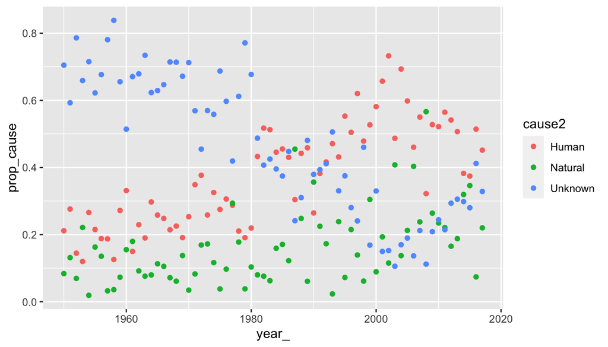

```r
calfire_causes %>%
    ggplot() +
    geom_point(aes(year_, prop_cause, color = cause2))
```

### Question 9

The file `calfire_damage.csv` contains information on the number of structures damaged each year by the wildfires in California. Import the file into R, join the information on the damaged structures with the `calfire` data frame and answer the following questions: - Is the number of damaged structures related to the size of the largest fire per year? *Hint: you can either produce a table with both variables per year or a chart using `plot()` or `geom_point()` from ggplot2*

```r
calfire_damage <- read_csv(here("static/exam/data/calfire_damage.txt"))
```

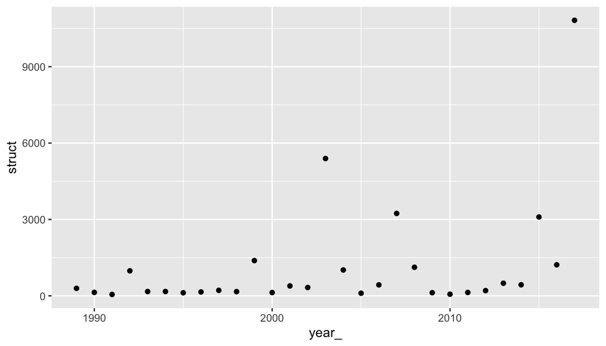

```r
inner_join(calfire, calfire_damage,
                          by = c("year_" = "year"))%>%
    group_by(year_) %>%
    summarise(size= max(sup_ha),
              struct = mean(structures)) %>%
    ggplot() +
    geom_point(aes(year_, struct))
```

### Question 10

The `cal_fire_incident` contains information of the total number of fires per year across the continental United States, the total of acres burned, and the total damage caused by the fires, in dollars. Import the file into R, reclassify the variable years into decades, and determine which was the most catastrophic decade in total number of fires, in total damage, and in acres burned. Moreover, determine in which decade there was a higher mean damage per fire.

```r
us_fires <- read_csv(here("static/exam/data/US_fire_incidents.txt"),
                                   skip = 1)
us_fires %>%
    mutate(decades = cut_width(YEAR, 10)) %>%
    group_by(decades) %>%
    summarise(n = sum(n_fires),
              acres = sum(acres_burned),
              damage = sum(dollars_damage),
              mean_damage = damage/n)
```

```
## # A tibble: 10 x 5
##    decades         n   acres     damage mean_damage
##    <fct>       <dbl>   <dbl>      <dbl>       <dbl>
##  1 [1925,1935]  5779  619524    1047889        181.
##  2 (1935,1945] 35337 4283064   10506451        297.
##  3 (1945,1955] 22421 1756264   17270942        770.
##  4 (1955,1965] 41005 1574454   26195658        639.
##  5 (1965,1975] 64625 1106497   81062103       1254.
##  6 (1975,1985] 70068 1296495  289086417       4126.
##  7 (1985,1995] 72233 1216394  580827506       8041.
##  8 (1995,2005] 60463 1601118 1785411374      29529.
##  9 (2005,2015] 37397 2230388 4635524295     123954.
## 10 (2015,2025]  3233  250996  148266893      45860.
```

## Coding Style and Organization

In addition to the answers, and the code needed to generate them, **10% of the final grade will be determined by the coding style and organization**. In this category we will value a variety of features, including, but not limited to the following:

- Content:
  - Questions answered in order
  - A written explanation of approach included for each question, if needed
  - Appropriate formatting of text and headings: fonts not larger than necessary, headings used properly, etc.
- Code formatting:
  - Rmarkdown document knits correctly and produces the desired output
  - Use tidyverse code
  - Spaces around `=`, after `#`, after `,`, etc.
  - New line for each `dplyr` function (lines end in `%>%`) or `ggplot` layer (lines end in `+`)
  - Proper indentation of pipes and ggplot layers
  - No unwanted / commented out code left behind in the document